# QQQ Report

Lecture 20

## Report format using QQQ

1. Qualitative:
   - Question, problem, hypothesis, claim, context, motivation
   - Definitions, data, methods to be used
   - Rationale, assumptions, biases
1. Quantitative:
   - Data processing, analysis, visualization
   - Documented code and results
   - Summary visuals
1. Qualitative:
   - Answer, update question/claim, summary, re-contextualization, story, relate to domain knowledge
   - Uncertainty, limitations, caveats
   - New problems, next steps
1. Repeat. QQQ-QQQ-QQQ-...
   - Break down a large problem into parts
   - Alternative approaches to a problem
   - Sequence of related problems, "vignettes"
   - Follow-up problems

### References:

- Good example of a Jupyter Notebook report: https://nbviewer.jupyter.org/gist/nealcaren/5105037
- QQQ: https://www.bava.stat.vt.edu/wp-content/uploads/2017/08/Developing-a-New-Interdisciplinary-Computational-Analytics-Undergraduate-Program-A-Qualitative-Quantitative-Qualitative-Approach.pdf
- Using visuals to support claims: https://www.cbre.com/research-and-reports/Scoring-Tech-Talent-in-North-America-2018
- Typical industry spam: https://www.seagate.com/files/www-content/our-story/trends/files/idc-seagate-dataage-whitepaper.pdf

# Why ACC is almost the best (and rankings are wrong)?

Which NCAA basketball conference is best? I think ACC did really well last year. Every year my buddies argue about which conf is the best, so lets settle the issue.

How can we define "best'? A good conf is defined by containing good schools. A the good-ness of a school is defined by its ranking. We will assume rankings from NCAAA https://www.ncaa.com/rankings/basketball-men/d1/ncaa-mens-basketball-net-rankings

detail on what we do below...

In step 1 we scrape the data from NCAA rankings and capture the Ranking School name and COnf name. We output the number of schools ranked.

```python
###
import requests, bs4, pandas

url = 'https://www.ncaa.com/rankings/basketball-men/d1/ncaa-mens-basketball-net-rankings'

schools = pandas.DataFrame(
    [(int(r.contents[1].text), r.contents[5].text, r.contents[7].text)
        for r in
            bs4.BeautifulSoup(requests.get(url).text, 'html5lib')
                .find_all('tr')[1:]],
    columns=['Ranking','School','Conference'])

len(schools)
```

```
353
```

```python
schools.set_index('Ranking')
```

| Ranking | School | Conference |
| --- | --- | --- |
| 1 | Virginia | ACC |
| 2 | Gonzaga | WCC |
| 3 | Duke | ACC |
| 4 | Kentucky | SEC |
| 5 | Michigan St. | Big Ten |
| ... | ... | ... |
| 349 | Mississippi Val. | SWAC |
| 350 | UNC Asheville | Big South |
| 351 | Delaware St. | MEAC |
| 352 | UMES | MEAC |
| 353 | Chicago St. | WAC |

353 rows × 2 columns

In step 2, we aggregate the schools by conf, using mean ranking and output the mean ranmk for each conf.

```python
###
conf = schools.groupby('Conference').mean().sort_values('Ranking')
conf['Mean Ranking'] = conf.Ranking.map(round)
conf[['Mean Ranking']]
```

| Conference | Mean Ranking |
| --- | --- |
| Big 12 | 39 |
| Big Ten | 47 |
| SEC | 54 |
| ACC | 64 |
| Big East | 64 |
| AAC | 94 |
| Pac-12 | 101 |
| WCC | 133 |
| MAC | 136 |
| Ivy League | 157 |
| Atlantic 10 | 158 |
| MWC | 169 |
| C-USA | 169 |
| MVC | 173 |
| SoCon | 177 |
| WAC | 179 |
| Sun Belt | 187 |
| CAA | 200 |
| Horizon | 213 |
| Patriot | 216 |
| ASUN | 217 |
| Big South | 220 |
| Big West | 228 |
| OVC | 230 |
| Summit League | 241 |
| America East | 242 |
| Big Sky | 244 |
| MAAC | 272 |
| NEC | 274 |
| Southland | 275 |
| SWAC | 306 |
| MEAC | 318 |

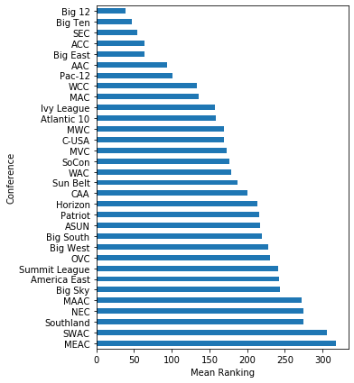

```python
%matplotlib inline
chart = conf['Mean Ranking'].sort_values(ascending=False).plot.barh(figsize=(5,7), sharex=True)
chart.set_xlabel('Mean Ranking');
#chart.grid()
```

Admittedly, this is only one way to compute the 'best' conf. It would be interesting to compare the results to some other ways to compute best, like .... counting # teams in top 25.

In future work, Maybe looking at Median as an aggregation measure would overcome some issues of skew in the conf rankings...